# Final Assignment

### 3) Diving Deeper

*Beside the gender ratio of superheroes and their alignment, we can also investigate their character representation.*

1. Count the number of powers for each superhero using the ‘powers’ dataset and add this count as a column `pwrs_cnt` to the `powers` dataframe. Join the `pwrs_cnt` column to the `heroes` dataframe.

```r
names(powers)[1] <- "name"
powers[,-1] <- lapply(powers[,-1], as.logical)
powers <- powers %>%
    mutate(pwrs_cnt = rowSums(.[2:ncol(powers)]))
index <- match(heroes_filter$name,powers$name)
powers_filter <- (powers[index,])
heroes_filter$pwrs_cnt <- powers_filter$pwrs_cnt
```

2. Make a plot showing the distribution of `pwrs_cnt` for each of the genders.

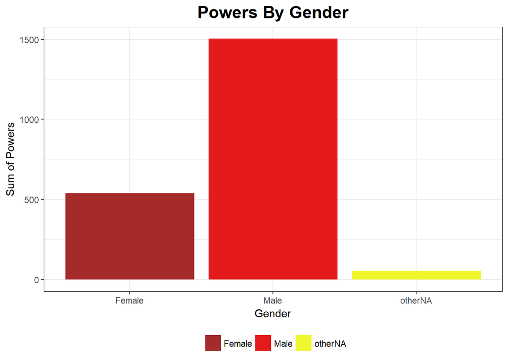

```r
plot4 <- ggplot(data = heroes_filter, aes(x=Gender, y=pwrs_cnt, fill=Gender)) +
    geom_bar(stat = "identity") +
    labs(title = "Powers By Gender", x='Gender',y='Sum of Powers') +
    theme_bw() +
    theme(plot.title = element_text(size=17, hjust = 0.5, face = "bold"), legend.position = "bottom", legend.title=element_blank()) +
    scale_fill_manual(values = c("#A52A2A", "#E41A1C","#EFF62E"))

plot4
```

3. Check if the distribution of `pwrs_cnt` by gender follows the normal distribution.

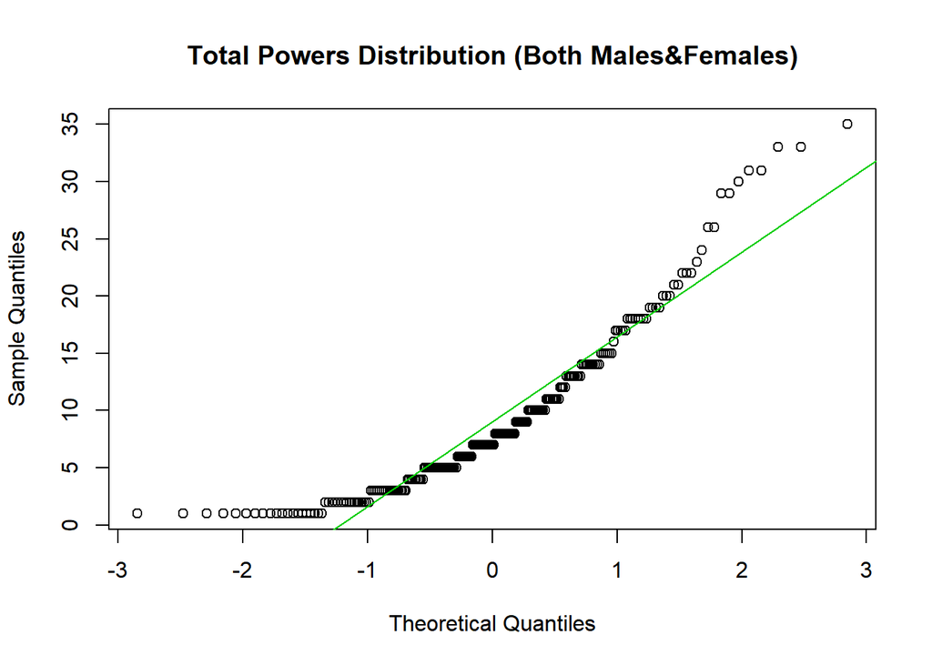

```r
dat3<-heroes_filter %>% group_by(name,Gender,pwrs_cnt) %>% summarise(number = n()) %>% arrange(-number)

pwrs_cnt_male <- dat3$pwrs_cnt[dat3$Gender=="Male"]
pwrs_cnt_male <- pwrs_cnt_male[!is.na(pwrs_cnt_male)]
pwrs_cnt_female <- dat3$pwrs_cnt[dat3$Gender=="Female"]
pwrs_cnt_female <- pwrs_cnt_female[!is.na(pwrs_cnt_female)]

qqnorm(heroes_filter$pwrs_cnt, main = "Total Powers Distribution (Both Males&Females)",xlab = "Theoretical Quantiles");qqline(pwrs_cnt_male, col = 3)
```

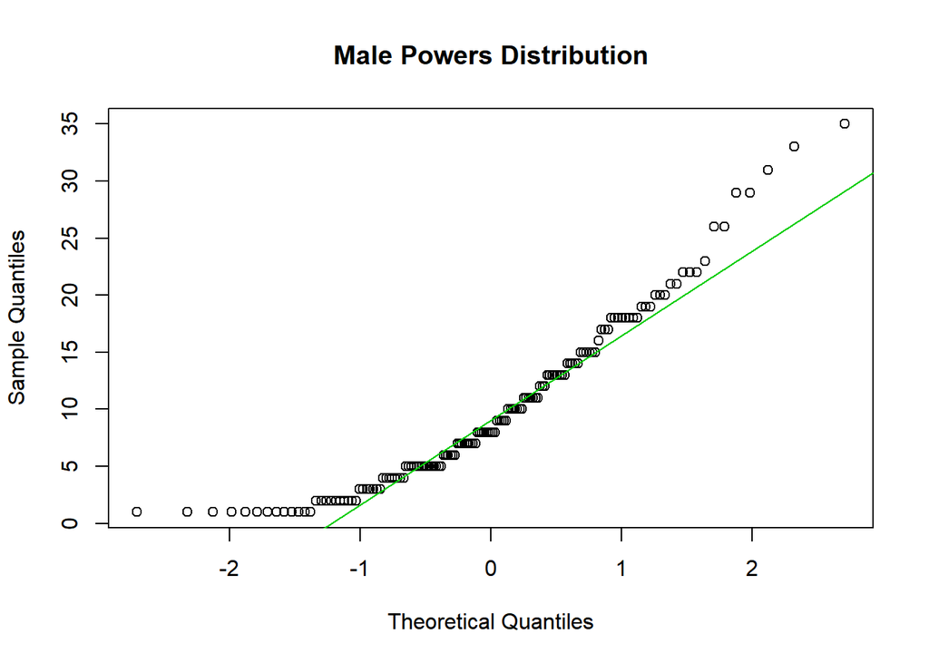

```r
qqnorm(pwrs_cnt_male, main = "Male Powers Distribution",xlab = "Theoretical Quantiles");qqline(pwrs_cnt_male, col = 3)
```

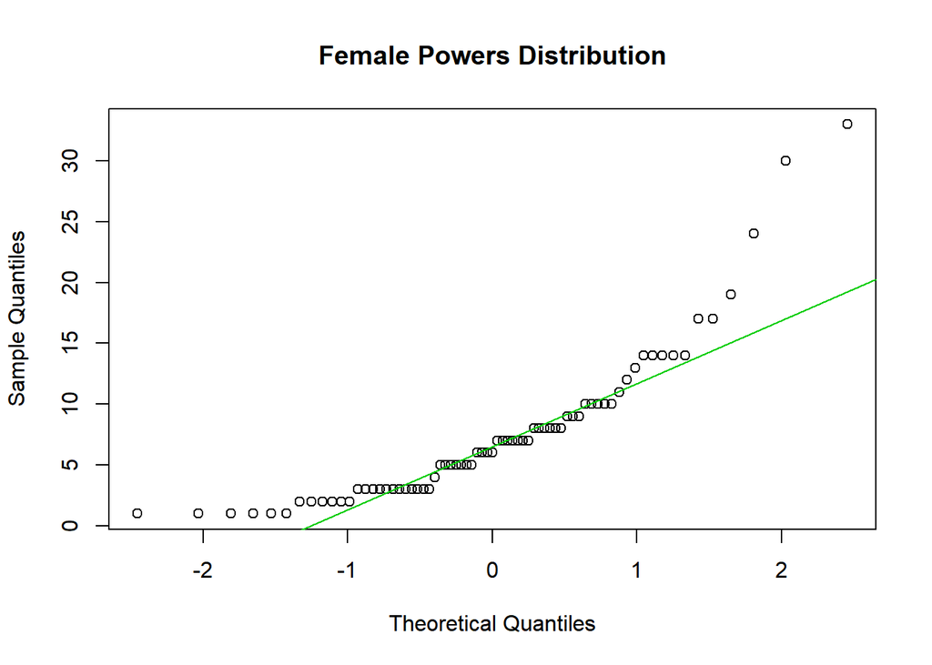

```r
qqnorm(pwrs_cnt_female,main = "Female Powers Distribution");qqline(pwrs_cnt_female, col = 3)
```

```r
##  We can see the data is quit skewed with long right tail
```

4. Use a location test to test if there is a difference between the gender power counts.

```r
mean_male = pwrs_cnt_male - mean(pwrs_cnt_male)
mean_female = pwrs_cnt_female - mean(pwrs_cnt_female)

num <- 10^5
mean_samp = vector()
for(i in 1:num){
  x_samp = sample(mean_male,replace = TRUE)
  y_samp = sample(mean_female, replace = TRUE)
  mean_samp[i] = diff(c(mean(x_samp) , mean(y_samp)))
}
sum(mean_samp >= 0)/length(mean_samp)
```

```
## [1] 0.49473
```

```r
## we get approximately 0.5 so we do not reject the null hypothesis
```